# Lake Eutrophication and Water Quality Classification Model

Author

Lauren Chetley & Emma Rodriguez

Published

May 27, 2026

# 1 Lake Water Quality Contract

## 1.1 Overall Program Description

The purpose of this program is to simulate and classify lake water quality conditions across a full water year (October through September) using daily environmental data. The model integrates nutrient concentrations, dissolved oxygen levels, and surface water temperatures to estimate overall monthly lake water quality risk. The program is organized into multiple connected modules, where each module processes environmental data independently before contributing to the final integrated water quality classification model.

The program uses simulated daily environmental observations, aggregates them into monthly means, and applies classification thresholds to evaluate changing lake conditions throughout the water year.

## 1.2 Module Parameters

### 1.2.1 Nutrients (Phosphorus and Nitrogen) Module

- Function: `nutrient_function`

Inputs:

- Daily lake phosphorus concentrations (mg/L)
- Daily lake nitrogen concentrations (mg/L)
- Expected input length: 365 daily observations per water year (October - September)

Processing:

- Daily nutrient values aggregated into monthly mean concentrations by water year
- Monthly nutrient classifications assigned based on phosphorus and nitrogen thresholds

Outputs:

- Monthly lake productivity risk classifications

Phosphorus = P and Nitrogen = N

- Oligotrophic: Low Productivity  
  P < 0.01 mg/L, N < 0.35 mg/L
- Mesotrophic: Medium Productivity  
  P 0.01 - 0.03 mg/L, N 0.36 - 0.65 mg/L
- Eutrophic: High Productivity  
  P 0.03 - 0.10 mg/L, N 0.65 - 1.20 mg/L
- Hypereutrophic: Very High Productivity  
  P > 0.10 mg/L, N > 1.20 mg/L

### 1.2.2 Dissolved Oxygen Module

- Function: `dissoxygen_function`

Inputs:

- Daily lake dissolved oxygen levels (mg/L)
- Expected input length: 365 daily observations per water year (October - September)

Processing:

- Daily dissolved oxygen values aggregated into monthly mean dissolved oxygen concentrations by water year
- Monthly dissolved oxygen classifications assigned based on oxygen thresholds

Outputs:

- Mean lake dissolved oxygen classifications
- Excellent DO: > 8 mg/L
- Moderate DO: 5 - 8 mg/L
- Stressful DO: 2 - 5 mg/L
- Hypoxic DO: < 2 mg/L

### 1.2.3 Surface Water Temperature Module

- Function: `temperature_function`

Inputs:

- Daily lake surface water temperatures (ºC)
- Expected input length: 365 daily observations per water year (October - September)

Processing:

- Daily surface water temperatures aggregated into monthly mean temperatures by water year
- Monthly temperature classifications assigned based on temperature thresholds

Outputs:

- Mean lake temperature classifications
- Cool: Below Average < 13ºC
- Mild: Average 13ºC - 22ºC
- Warm: Above Average 22ºC - 30ºC
- Hot: Boiling > 30ºC

### 1.2.4 Lake Water Quality Module Parameters

- Function: `water_quality_model`

Inputs:

- Monthly nutrient productivity classifications
- Monthly dissolved oxygen classifications
- Monthly surface water temperature classifications
- Expected inputs generated from 365 daily observations per water year (October - September)

Functions Used:

- `nutrient_function`
- `dissoxygen_function`
- `temperature_function`

Processing:

- Monthly classifications from each environmental module are combined within the final water quality model
- A for loop is used to apply the final classification model across each month of the water year

Outputs:

- Final monthly lake water quality risk classifications
- Low Risk: Oligotrophic, Excellent DO, Cool Temperature
- Moderate Risk: Mesotrophic, Moderate DO, Mild Temperature
- High Risk: Eutrophic, Stressful DO, Warm Temperature
- Extreme Risk: Hypereutrophic, Hypoxic DO, Hot Temperature

# 2 Flow Chart / Diagram

Download Full Flow Chart PDF

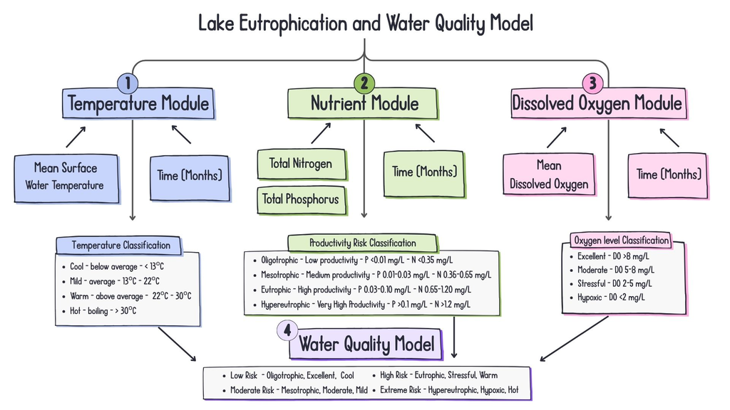

# 3 Final Lake Water Quality Model

```r
# Script for Final Water Quality Model

# loading libraries
library(tidyverse)
library(here)

# load in the model functions
source(here("scripts", "nutrient_module_script.R"))
source(here("scripts", "dissoxygen_module_script.R"))
source(here("scripts", "temperature_module_script.R"))

# load in the data
nutrientdata <- read.csv(here("data", "nutrient_data.csv"))
dissoxygendata <- read.csv(here("data", "dissoxygen_data.csv"))
temperaturedata <- read.csv(here("data", "temperature_data.csv"))

# run each model
nutrient_results <- nutrient_function(nutrientdata)
dissoxygen_results <- dissoxygen_function(dissoxygendata)
temperature_results <- temperature_function(temperaturedata)

# combine model outputs by month
water_quality_data <- nutrient_results |>
  select(month, nutrient_class = classification) |>
  left_join(
    dissoxygen_results |>
      select(month, dissoxygen_class = classification),
    by = "month"
  ) |>
  left_join(
    temperature_results |>
      select(month, temperature_class = classification),
    by = "month"
  )

# final water quality classification function
water_quality_model <- function(nutrient_class,
                                dissoxygen_class,
                                temperature_class) {

  if (nutrient_class == "Hypereutrophic" ||
      dissoxygen_class == "Hypoxic" ||
      temperature_class == "Hot - Boiling") {

    final_class <- "Extreme Risk"

  } else if (nutrient_class == "Eutrophic" ||
             dissoxygen_class == "Stressful" ||
             temperature_class == "Warm - Above Average") {

    final_class <- "High Risk"

  } else if (nutrient_class == "Mesotrophic" ||
             dissoxygen_class == "Moderate" ||
             temperature_class == "Mild - Average") {

    final_class <- "Moderate Risk"

  } else {

    final_class <- "Low Risk"
  }

  return(final_class)
}

# apply final model
water_quality_results <- water_quality_data |>
  mutate(
    final_water_quality = mapply(
      water_quality_model,
      nutrient_class,
      dissoxygen_class,
      temperature_class
    )
  )

# show final results
print(water_quality_results)
```

```
# A tibble: 12 × 5
   month   nutrient_class dissoxygen_class temperature_class final_water_quality
   <fct>   <chr>          <chr>            <chr>             <chr>
 1 October Oligotrophic   Excellent        Cool - Below Ave… Low Risk
 2 Novemb… Mesotrophic    Moderate         Cool - Below Ave… Moderate Risk
 3 Decemb… Oligotrophic   Excellent        Cool - Below Ave… Low Risk
 4 January Oligotrophic   Excellent        Cool - Below Ave… Low Risk
 5 Februa… Mesotrophic    Excellent        Cool - Below Ave… Moderate Risk
 6 March   Mesotrophic    Moderate         Mild - Average    Moderate Risk
 7 April   Eutrophic      Moderate         Mild - Average    High Risk
 8 May     Eutrophic      Stressful        Warm - Above Ave… High Risk
 9 June    Eutrophic      Stressful        Warm - Above Ave… High Risk
10 July    Oligotrophic   Hypoxic          Warm - Above Ave… Extreme Risk
11 August  Hypereutrophic Hypoxic          Hot - Boiling     Extreme Risk
12 Septem… Mesotrophic    Stressful        Warm - Above Ave… High Risk
```

# 4 Lake Water Quality Visualization Module

## 4.1 Graph 1

```r
# Water Quality Visualization Script

library(tidyverse)
library(here)
# -------------------------------------------------------------------
# Plot 1: Monthly Final Water Quality Classification
#
# This figure displays the overall monthly lake water quality risk
# classification produced by the integrated water quality model.
# -------------------------------------------------------------------

# Set factor order for water quality classifications
water_quality_results$final_water_quality <- factor(
  water_quality_results$final_water_quality,
  levels = c(
    "Low Risk",
    "Moderate Risk",
    "High Risk",
    "Extreme Risk"
  )
)


# Create visualization
wqm_classification_bargraph <- ggplot(
  water_quality_results,
  aes(
    x = month,
    y = final_water_quality,
    fill = final_water_quality
  )
) +
  geom_col(color = "black", width = 0.7) +
  labs(
    title = "Monthly Final Lake Water Quality Classification By Water Year",
    x = "Month",
    y = "Water Quality Risk Classification",
    fill = "Risk Level"
  ) +
  scale_fill_manual(values = c(
    "Low Risk" = "#66c2a5",
    "Moderate Risk" = "#ffd166",
    "High Risk" = "#f4a261",
    "Extreme Risk" = "#d62828"
  )) +
  theme_minimal() +
  theme(
    plot.title = element_text(face = "bold", size = 16),
    axis.title = element_text(face = "bold"),
    axis.text.x = element_text(angle = 45, hjust = 1),
    legend.title = element_text(face = "bold")
  )


wqm_classification_bargraph
```

[figure not shown]

## 4.2 Graph 2

```r
# -------------------------------------------------------------------
# Plot 2: Monthly Environmental Conditions by Module
#
# This figure displays the monthly mean phosphorus, nitrogen,
# dissolved oxygen, and temperature values used in the lake
# water quality model. The plot highlights seasonal environmental
# patterns across the water year.
# -------------------------------------------------------------------

# Combine monthly model outputs
visual_data <- nutrient_results |>
  select(month,
         mean_phosphorus,
         mean_nitrogen) |>
  left_join(
    dissoxygen_results |>
      select(month, mean_dissoxygen),
    by = "month"
  ) |>
  left_join(
    temperature_results |>
      select(month, mean_temp_c),
    by = "month"
  )

# Convert to long format for plotting
visual_data_long <- visual_data |>
  pivot_longer(
    cols = c(mean_phosphorus,
             mean_nitrogen,
             mean_dissoxygen,
             mean_temp_c),
    names_to = "variable",
    values_to = "value"
  )

# Create visualization
monthly_conditions_linegraph <- ggplot(visual_data_long,
       aes(x = month,
           y = value,
           color = variable,
           group = variable)) +
  geom_line(size = 1.2) +
  geom_point(size = 3) +
  labs(
    title = "Monthly Lake Environmental Conditions By Water Year",
    x = "Month",
    y = "Mean Monthly Value",
    color = "Environmental Variable"
  ) +
  scale_color_manual(values = c(
    "mean_phosphorus" = "darkorange",
    "mean_nitrogen" = "forestgreen",
    "mean_dissoxygen" = "steelblue",
    "mean_temp_c" = "firebrick"
  ),
  labels = c(
      "mean_phosphorus"  = "Phosphorus (mg/L)",
      "mean_nitrogen"    = "Nitrogen (mg/L)",
      "mean_dissoxygen"  = "Dissolved Oxygen (mg/L)",
      "mean_temp_c"      = "Surface Water Temperature (°C)")) +
  theme_minimal() +
  theme(
    plot.title = element_text(face = "bold"),
    axis.text.x = element_text(angle = 45, hjust = 1)
  )
monthly_conditions_linegraph
```

[figure not shown]

## 4.3 Visualization 1: Monthly Final Water Quality Classification

The final water quality classification model showed clear seasonal patterns in lake conditions throughout the water year based on the simulated environmental data. Winter months such as October, December, and January were generally classified as Low Risk because they had low nutrient concentrations, high dissolved oxygen levels, and cool water temperatures. Moderate Risk conditions occurred during transition periods with moderate nutrient concentrations and environmental conditions, while High Risk and Extreme Risk conditions became more common during warmer months with elevated nutrient concentrations and lower dissolved oxygen levels. August showed the most severe conditions due to the combination of hypereutrophic nutrient levels, hypoxic dissolved oxygen conditions, and extremely warm water temperatures.

## 4.4 Visualization 2: Monthly Environmental Conditions

The environmental conditions visualization highlighted strong seasonal trends in nutrient concentrations, dissolved oxygen, and surface water temperatures across the simulated water year. Nutrient concentrations generally increased during spring and summer months, representing increased agricultural runoff and warmer seasonal conditions, while dissolved oxygen levels declined during warmer periods. Surface water temperatures steadily increased into summer and peaked during July and August. Together, these environmental patterns helped explain the changes observed in the final water quality risk classifications generated by the integrated lake model.